MULTIPLE LINEAR REGRESSION ON SALES PREDICTION ON CAR SEATS

**Data Description**

#### The Carseats data set tracks sales information for car seats. It has 400 observations (each at a different store) and 11 variables. the porpuse is to predict number of unit sales in each condition.

##### **Sales:** Unit sales in thousands

##### **CompPrice:** Price charged by competitor at each location

##### **Income:** Community income level in 1000s of dollars

##### **Advertising:** Local ad budget at each location in 1000s of dollars

##### **Population:** Regional pop in thousands

##### **Price:** Price for car seats at each site

##### **ShelveLoc:** Bad, Good or Medium indicates quality of shelving location

##### **Age:** Age level of the population

##### **Education:** Education level at location

##### **Urban:** Yes/No

##### **US:** Yes/No

**R Packages**

```r
library(corrplot)           #visualization of correlation
library(dplyr)              #used for data transformations
library(moments)            #used for calculating skweness and kurtosis
library(car)                #used for functions that perform tests,transform data etc
```

**Data Reading and Understanding**

```r
seats_sales=read.csv("C:\\Users\\Shruti Saraf\\OneDrive\\Desktop\\Project\\Sales Prediction of Carseats.csv")

View(seats_sales)

glimpse(seats_sales)
```

```
## Rows: 400
## Columns: 12
## $ No          <int> 1, 2, 3, 4, 5, 6, 7, 8, 9, 10, 11, 12, 13, 14, 15, 16, 17,…
## $ Sales       <dbl> 9.50, 11.22, 10.06, 7.40, 4.15, 10.81, 6.63, 11.85, 6.54, …
## $ CompPrice   <int> 138, 111, 113, 117, 141, 124, 115, 136, 132, 132, 121, 117…
## $ Income      <int> 73, 48, 35, 100, 64, 113, 105, 81, 110, 113, 78, 94, 35, 2…
## $ Advertising <int> 11, 16, 10, 4, 3, 13, 0, 15, 0, 0, 9, 4, 2, 11, 11, 5, 0, …
## $ Population  <int> 276, 260, 269, 466, 340, 501, 45, 425, 108, 131, 150, 503,…
## $ Price       <int> 120, 83, 80, 97, 128, 72, 108, 120, 124, 124, 100, 94, 136…
## $ ShelveLoc   <chr> "Bad", "Good", "Medium", "Medium", "Bad", "Bad", "Medium",…
## $ Age         <int> 42, 65, 59, 55, 38, 78, 71, 67, 76, 76, 26, 50, 62, 53, 52…
## $ Education   <int> 17, 10, 12, 14, 13, 16, 15, 10, 10, 17, 10, 13, 18, 18, 18…
## $ Urban       <chr> "Yes", "Yes", "Yes", "Yes", "Yes", "No", "Yes", "Yes", "No…
## $ US          <chr> "Yes", "Yes", "Yes", "Yes", "No", "Yes", "No", "Yes", "No"…
```

```r
summary(seats_sales)
```

```
##        No            Sales          CompPrice       Income
##  Min.   :  1.0   Min.   : 0.000   Min.   : 77   Min.   : 21.00
##  1st Qu.:100.8   1st Qu.: 5.390   1st Qu.:115   1st Qu.: 42.75
##  Median :200.5   Median : 7.490   Median :125   Median : 69.00
##  Mean   :200.5   Mean   : 7.496   Mean   :125   Mean   : 68.66
##  3rd Qu.:300.2   3rd Qu.: 9.320   3rd Qu.:135   3rd Qu.: 91.00
##  Max.   :400.0   Max.   :16.270   Max.   :175   Max.   :120.00
##   Advertising       Population        Price        ShelveLoc
##  Min.   : 0.000   Min.   : 10.0   Min.   : 24.0   Length:400
##  1st Qu.: 0.000   1st Qu.:139.0   1st Qu.:100.0   Class :character
##  Median : 5.000   Median :272.0   Median :117.0   Mode  :character
##  Mean   : 6.635   Mean   :264.8   Mean   :115.8
##  3rd Qu.:12.000   3rd Qu.:398.5   3rd Qu.:131.0
##  Max.   :29.000   Max.   :509.0   Max.   :191.0
##       Age          Education       Urban                US
##  Min.   :25.00   Min.   :10.0   Length:400         Length:400
##  1st Qu.:39.75   1st Qu.:12.0   Class :character   Class :character
##  Median :54.50   Median :14.0   Mode  :character   Mode  :character
##  Mean   :53.32   Mean   :13.9
##  3rd Qu.:66.00   3rd Qu.:16.0
##  Max.   :80.00   Max.   :18.0
```

**Data Cleaning**

```r
#Removing No column
seats_sales = seats_sales[,-1]

any(is.na(seats_sales))
```

```
## [1] FALSE
```

```r
seats_sales[duplicated(seats_sales),]
```

```
##  [1] Sales       CompPrice   Income      Advertising Population  Price
##  [7] ShelveLoc   Age         Education   Urban       US
## <0 rows> (or 0-length row.names)
```

**Checking and Removing Outliers**

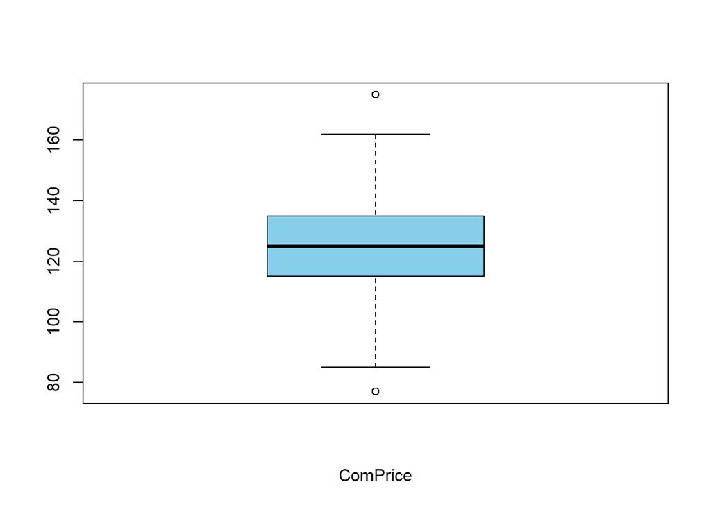

```r
boxplot(seats_sales$CompPrice , col = "skyblue" , xlab = "ComPrice")
```

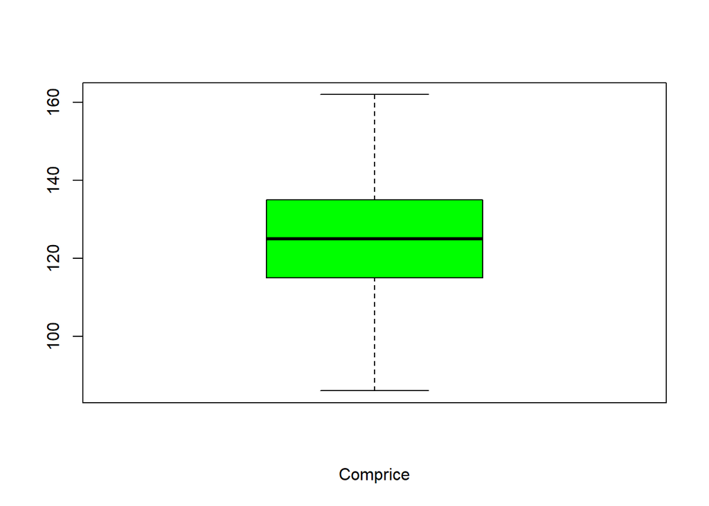

```r
CompPrice = seats_sales$CompPrice
Qu_3rd = summary(CompPrice)['3rd Qu.']
Qu_1st = summary(CompPrice)['1st Qu.']
IQR = Qu_3rd-Qu_1st
upper = Qu_3rd+1.5*IQR
lower = Qu_1st-1.5*IQR
index_out = which(CompPrice>=upper | CompPrice<=lower)
seats_sales1=seats_sales[-c(index_out),]
boxplot(seats_sales1$CompPrice , col = "green" , xlab = "Comprice")
```

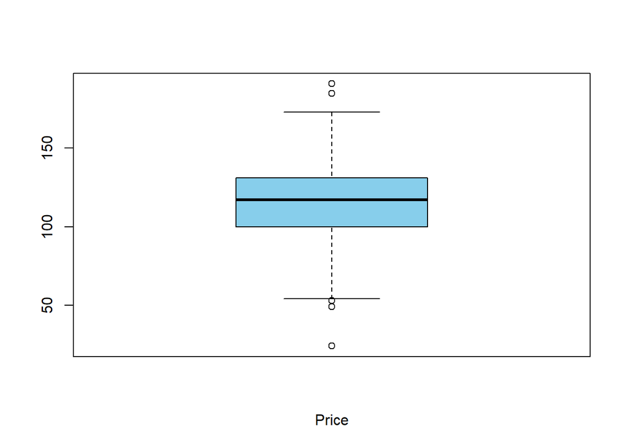

```r
boxplot(seats_sales$Price , col = "skyblue" , xlab = "Price")
```

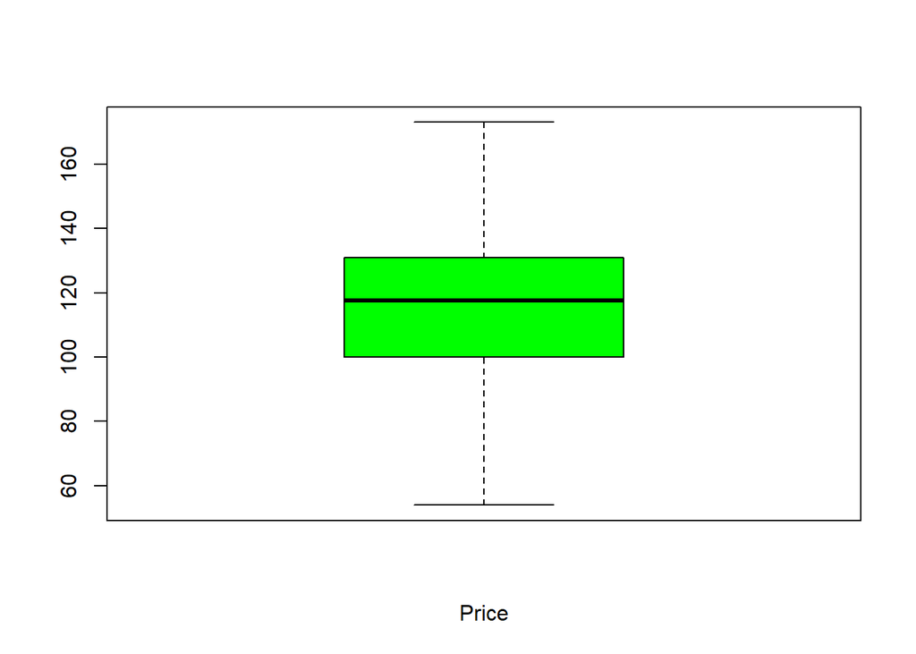

```r
Price = seats_sales$Price
Qu_3rd = summary(Price)['3rd Qu.']
Qu_1st = summary(Price)['1st Qu.']
IQR = Qu_3rd-Qu_1st
upper = Qu_3rd+1.5*IQR
lower = Qu_1st-1.5*IQR
index_out = which(Price>=upper | Price<=lower)
seats_sales1=seats_sales[-c(index_out),]
seats_sales1=seats_sales1[-166,]
boxplot(seats_sales1$Price , col = "green" , xlab = "Price" )
```

**Data Modelling**

```r
#MODEL 1

fit1=lm(Sales ~ CompPrice + Income + Advertising + Population + Price + ShelveLoc + Age + Education + Urban + US , data = seats_sales1)

summary(fit1)
```

```
##
## Call:
## lm(formula = Sales ~ CompPrice + Income + Advertising + Population +
##     Price + ShelveLoc + Age + Education + Urban + US, data = seats_sales1)
##
## Residuals:
##     Min      1Q  Median      3Q     Max
## -2.8720 -0.6835  0.0162  0.6642  3.3869
##
## Coefficients:
##                   Estimate Std. Error t value Pr(>|t|)
## (Intercept)      5.7571683  0.6148630   9.363  < 2e-16 ***
## CompPrice        0.0925990  0.0041862  22.120  < 2e-16 ***
## Income           0.0157675  0.0018623   8.467 5.49e-16 ***
## Advertising      0.1231996  0.0111694  11.030  < 2e-16 ***
## Population       0.0001598  0.0003747   0.426    0.670
## Price           -0.0954252  0.0027952 -34.139  < 2e-16 ***
## ShelveLocGood    4.8287844  0.1550088  31.152  < 2e-16 ***
## ShelveLocMedium  1.9537625  0.1274330  15.332  < 2e-16 ***
## Age             -0.0466221  0.0032239 -14.461  < 2e-16 ***
## Education       -0.0218125  0.0199413  -1.094    0.275
## UrbanYes         0.1238900  0.1143263   1.084    0.279
## USYes           -0.1811487  0.1510770  -1.199    0.231
## ---
## Signif. codes:  0 '***' 0.001 '**' 0.01 '*' 0.05 '.' 0.1 ' ' 1
##
## Residual standard error: 1.022 on 382 degrees of freedom
## Multiple R-squared:  0.8676, Adjusted R-squared:  0.8638
## F-statistic: 227.6 on 11 and 382 DF,  p-value: < 2.2e-16
```

#### **Interpretation**:- According to standards, p_value is greater than 0.05, we can remove the feature because overfitting occurs. In last table, Population, Education, Urban and US have p_value greater than 0.05. Thus we must remove these features using Backward Elimination and reassign model.

```r
#MODEL 2

fit2=lm(Sales ~ CompPrice + Income + Advertising + Price + ShelveLoc + Age , data = seats_sales1)

summary(fit2)
```

```
##
## Call:
## lm(formula = Sales ~ CompPrice + Income + Advertising + Price +
##     ShelveLoc + Age, data = seats_sales1)
##
## Residuals:
##     Min      1Q  Median      3Q     Max
## -2.7720 -0.6963  0.0299  0.6763  3.3065
##
## Coefficients:
##                  Estimate Std. Error t value Pr(>|t|)
## (Intercept)      5.547875   0.519631  10.677  < 2e-16 ***
## CompPrice        0.092371   0.004158  22.217  < 2e-16 ***
## Income           0.015738   0.001854   8.488 4.57e-16 ***
## Advertising      0.115939   0.007800  14.865  < 2e-16 ***
## Price           -0.095365   0.002794 -34.138  < 2e-16 ***
## ShelveLocGood    4.813468   0.154212  31.213  < 2e-16 ***
## ShelveLocMedium  1.948219   0.126714  15.375  < 2e-16 ***
## Age             -0.046683   0.003215 -14.522  < 2e-16 ***
## ---
## Signif. codes:  0 '***' 0.001 '**' 0.01 '*' 0.05 '.' 0.1 ' ' 1
##
## Residual standard error: 1.023 on 386 degrees of freedom
## Multiple R-squared:  0.8662, Adjusted R-squared:  0.8637
## F-statistic: 356.9 on 7 and 386 DF,  p-value: < 2.2e-16
```

#### **Interpretation**:- In this table, NO features have p_value greater than 0.05. It means that remaining all the features are significant. In this situation we sure that overfitting not occur and model is ready.

**Linear Model Assumptions**

#### 1) LINEARITY

#### 2) NORMALITY OF ERROR COMPONENTS

#### 3) HOMOSCEDASTICITY (CONSTANT STANDARD DEVIATION)

#### 4) NO OR MULTICOLLINEARITY

#### 5) NO AUTOCORRELATION

**1) Linearity**

#### The Linearity assumption can be checked using plot of FITTED VALUES Vs RESIDUAL

**2) Normality of Error Components**

#### The Normality assumption can be checked using Normal Q-Q plot

**3) Homoscedasticity (Constant Standard Deviation)**

#### The Homoscedasticity assumption can be checked using plot of FITTED VALUES Vs RESIDUAL

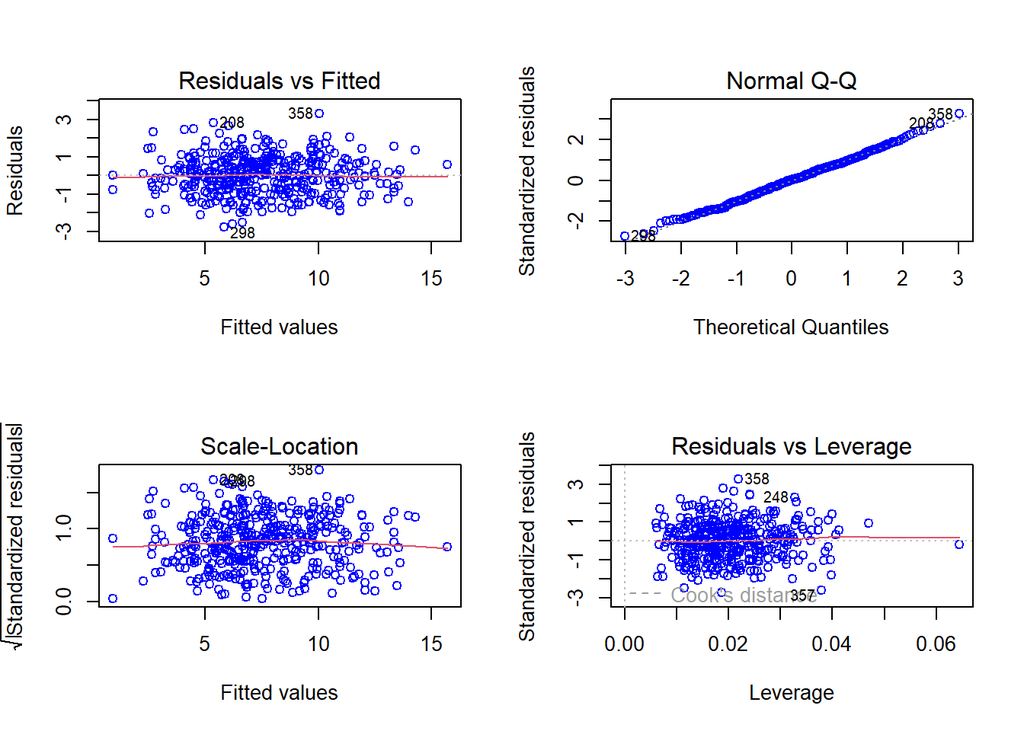

```r
par(mfrow=c(2,2))
plot(fit2, col = "blue")
```

#### **Interpretation for Linearity**:- We have plotted graphs. The first graph shows the fitted values against the observed residuals. In this plot the dots should be randomly placed around the horizontal zero line, which is clear in this case. Hence the “LINEARITY” ASSUMPTION is Satisfied.

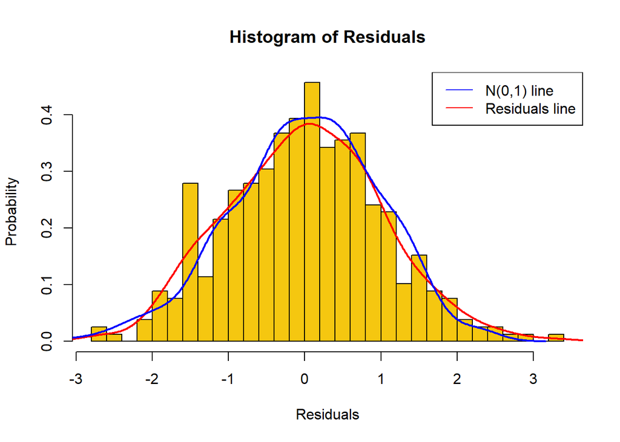

```r
set.seed(23)
hist(summary(fit2)$residuals,col = 71,probability = T ,
     main = "Histogram of Residuals",
     xlab = "Residuals",
     ylab = "Probability",
     border = "black",
     breaks = 30)
x=summary(fit2)$residuals
lines(density(x),col="red",lwd=2)
y=rnorm(length(summary(fit2)$residuals))
lines(density(y),col="blue",lwd=2)
legend("topright",legend = c("N(0,1) line","Residuals line"),col = c("blue","red"),lty = 1:1)
```

```r
skewness(fit2$residuals)
```

```
## [1] 0.1005404
```

```r
kurtosis(fit2$residuals)
```

```
## [1] 2.924889
```

#### **Interpretation for Normality**:- We have plotted graphs. The second graph shows the Normaal Q-Q plot. In this plot the dots should be placed approximately on Normal line i.e. N(0,1) line, which is clear in this case. Hence the “Normality” ASSUMPTION is Satisfied.Also the skewness and kurtosis of residuals is 0.10 and 2.92 respectively which is approximately 0 and 3 i.e. skewness of N(0,1) and kurtosis of N(0,1).

#### **Interpretation for Homoscedasticity**:- We have plotted graphs. The first graph shows the fitted values against the observed residuals. In this plot the dots should be randomly placed in the plot i.e. the points should not follow any particular pattern, which is clear in this case. Hence the “HOMOSCEDASTICITY” ASSUMPTION is Satisfied.

**4) No Multicollinearity**

#### When checking the assumption of multicollinearity you check if one or more variables used in the model are not to strongly correlated amongst each other. Atleast the correlation between the predictors should not be to high (that is higher than 0.80). One way to check is this, is to make a correlation matrix with all predictor variables. An easier way is to look at the variance inflation factor (VIF). The VIF should not be higher than 10.

#### As we removed the insignificant variables from our model using Backward Elimination Mthod which is exactly same as removing multicollinearity from the data.

#### Verified “NO MULTICOLLINEARITY”, using CORRPLOT and VARIANCE INFLATION FACTOR (VIF).

```r
#Correlation Matrix

seats_sales2=seats_sales1
seats_sales2$ShelveLoc=as.numeric(factor(seats_sales2$ShelveLoc))

seats_sales2=seats_sales2[,-c(1,2,6,10,11,12)]
corr_mtx=round(cor(seats_sales2),1);corr_mtx
```

```
##             Income Advertising Population ShelveLoc  Age Education
## Income         1.0         0.1        0.0      -0.1  0.0      -0.1
## Advertising    0.1         1.0        0.3       0.0  0.0       0.0
## Population     0.0         0.3        1.0       0.0 -0.1      -0.1
## ShelveLoc     -0.1         0.0        0.0       1.0  0.1       0.0
## Age            0.0         0.0       -0.1       0.1  1.0       0.0
## Education     -0.1         0.0       -0.1       0.0  0.0       1.0
```

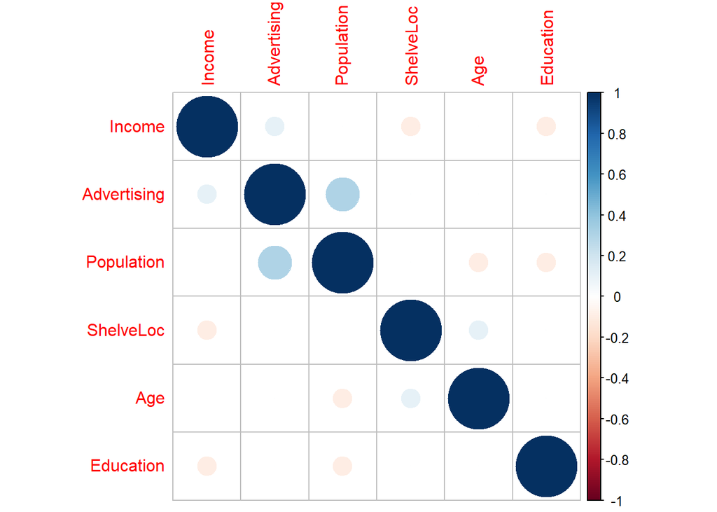

```r
corrplot(corr_mtx)
```

```r
# Variance Inflation Factor
vif(fit2)
```

```
##                 GVIF Df GVIF^(1/(2*Df))
## CompPrice   1.465001  1        1.210372
## Income      1.014232  1        1.007091
## Advertising 1.013636  1        1.006795
## Price       1.465550  1        1.210599
## ShelveLoc   1.019495  2        1.004839
## Age         1.019624  1        1.009764
```

#### 2] A VIF larger than 10 indicates multicolinearity. We have no VIF larger than 10, so this indicates no multicollinearity.

#### Hence “NO MULLTICOLLINEARITY” ASSUMPTION IS SATISFIED

**5)No Autocorrelation**

#### The assumption of No Autocorrelation can be checked by ACF() function and Durbin-Watson test.

#### DURBIN-WATSON TEST TO CHECK AUTOCORRELATION

#### The Durbin-Watson test statistic has always a value between 0 and 4, where:[0-2): means positive autocorrelation,2: means no autocorrelation,(2-4]: mean negative autocorrelation.

#### As a rule of thumb, we assume that the residuals are not correlated when the Durbin-Watson test statistic has a value between 1.5 and 2.5. If the statistic is below 1 or above 3, then there is definitely autocorrelation among the residuals.

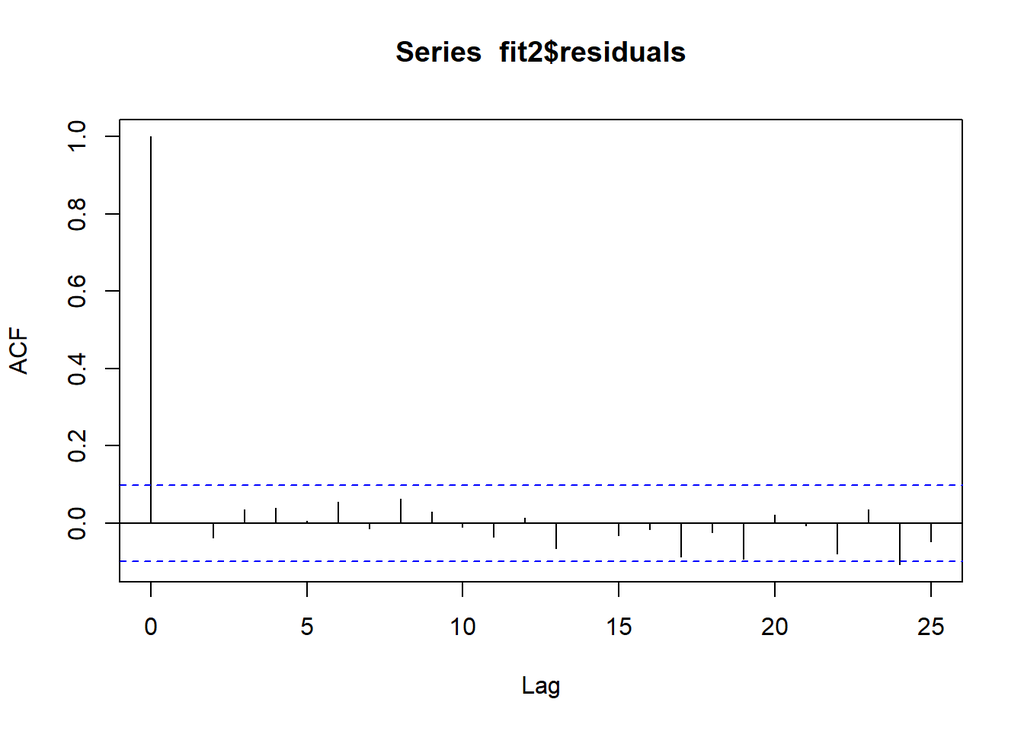

```r
acf(fit2$residuals,type = "correlation")
```

```r
durbinWatsonTest(fit2)
```

```
##  lag Autocorrelation D-W Statistic p-value
##    1   -0.0009317745      1.989998   0.894
##  Alternative hypothesis: rho != 0
```

#### Hence “NO AUTOCORRELATION” ASSUMPTION IS SATISFIED

*CONCLUSION:*

#### **1] Fitted Multiple Linear Regression model to evaluate the variable dependency on Sales using Backward Elimination Method.**

#### **2] Computed Adjusted R2 of 0.8637 after removing outliers and verified the Linear Regression Assumptions.**